# Multilevel Structure of G20 Trade Network

Algebraic analyses and visualization of complex networks* Sunbelt XLIII Conference – Workshop

Antonio Rivero Ostoic

CESU, University of San Simón

multiplex@post.com

23 June 2023

*Multilevel networks* combine affiliation with one-mode network.

## G20 Trade valued network

#### Affiliation network

```r
# retrieve G20 affiliation data
url("https://raw.githubusercontent.com/mplex/sunbelt2023/master/data/G20.rda") |>
  load()
```

```r
# G20 Affiliation network
G20
```

```
    P5 G4 G7 BRICS MITKA DAC OECD Cwth N11
ARG  0  0  0     0     0   0    0    0   0
AUS  0  0  0     0     1   1    1    1   0
BRA  0  1  0     1     0   0    0    0   0
CAN  0  0  1     0     0   1    1    1   0
CHN  1  0  0     1     0   0    0    0   0
DEU  0  1  1     0     0   1    1    0   0
FRA  1  0  1     0     0   1    1    0   0
GBR  1  0  1     0     0   1    1    1   0
IDN  0  0  0     0     1   0    0    0   1
IND  0  1  0     1     0   0    0    1   0
ITA  0  0  1     0     0   1    1    0   0
JPN  0  1  1     0     0   1    1    0   0
KOR  0  0  0     0     1   1    1    0   1
MEX  0  0  0     0     1   0    1    0   1
RUS  1  0  0     1     0   0    0    0   0
SAU  0  0  0     0     0   0    0    0   0
TUR  0  0  0     0     1   0    1    0   1
USA  1  0  1     0     0   1    1    0   0
ZAF  0  0  0     1     0   0    0    1   0
```

#### Trade valued network

```r
# retrieve G20 trade data
url("https://raw.githubusercontent.com/mplex/sunbelt2023/master/data/G20net.rda") |>
  load()
```

```r
# G20 Trade network
G20net
```

```
, , M

    ARG AUS BRA  CAN  CHN  DEU  FRA  GBR IDN IND ITA JPN KOR  MEX RUS SAU TUR USA ZAF
ARG   0   0   0    0    0    0    0    0   0   0   0   0   0    0   0   0   0   0   0
AUS   0   0   0    0    0    0    0    0   0   0   0   0 412    0   0   0   0   0   0
BRA   0   0   0    0    0    0    0    0   0   0   0   0   0    0   0   0   0   0   0
CAN   0   0   0    0    0    0    0    0   0   0   0   0   0    0   0   0   0 273   0
CHN   0   0   0    0    0    0    0    0   0   0   0   0   0    0   0   0   0   0   0
DEU   0   0   0    0    0    0 7358  928   0   0   0   0   0    0   0   0   0   0   0
FRA   0   0   0    0    0 7553    0 1345 443   0   0   0 921    0   0 960   0 254   0
GBR   0   0   0    0 1734  641 1170    0   0   0   0   0   0    0   0   0   0   0   0
IDN   0   0   0    0    0    0    0    0   0   0   0   0   0    0   0   0   0   0   0
IND   0   0   0    0    0    0    0    0   0   0   0   0   0    0   0   0   0   0   0
ITA   0   0   0    0    0    0  355    0   0   0   0   0   0    0   0   0   0   0   0
JPN   0   0   0    0    0    0    0    0   0   0   0   0   0    0   0   0   0   0   0
KOR   0   0   0    0 1743    0    0    0   0   0   0   0   0    0   0   0   0   0   0
MEX   0   0   0    0    0    0    0    0   0   0   0   0   0    0   0   0   0 752   0
RUS   0   0   0    0    0    0    0    0   0   0   0   0   0    0   0   0   0   0   0
SAU   0   0   0    0    0    0    0    0   0   0   0   0   0    0   0   0   0   0   0
TUR   0   0   0    0    0    0    0    0   0   0   0   0   0    0   0   0   0   0   0
USA   0   0   0 2493    0    0    0    0   0   0   0   0   0 2174   0   0   0   0   0
ZAF   0   0   0    0    0    0    0    0   0   0   0   0   0    0   0   0   0   0   0

, , H

    ARG  AUS BRA CAN CHN DEU  FRA GBR IDN IND ITA  JPN KOR MEX RUS  SAU TUR   USA ZAF
ARG   0  544   0   0   0   0    0   0 269   0 374    0   0   0   0  319   0     0   0
AUS   0    0   0 331 860   0    0   0   0   0   0    0   0   0   0    0   0     0   0
BRA   0    0   0 547   0 781    0 450   0   0   0    0   0   0   0    0   0     0   0
CAN   0    0   0   0   0   0    0   0   0   0   0    0   0   0   0    0   0     0   0
CHN   0 1187   0   0   0   0    0   0   0   0 874 5644   0   0   0    0   0     0   0
DEU   0    0   0   0 296   0 1585 577   0   0 493    0   0   0   0    0   0   295   0
FRA   0    0   0   0   0 331    0   0   0   0   0    0   0   0   0    0   0     0   0
GBR   0    0   0   0   0   0    0   0   0   0   0    0   0   0   0    0   0     0   0
IDN   0    0   0   0   0   0    0   0   0   0   0    0   0   0   0    0   0     0   0
IND   0    0   0   0   0   0    0   0   0   0   0    0   0   0   0  273   0 10906   0
ITA   0    0   0   0   0   0 1245 252   0   0   0    0   0   0   0    0   0     0   0
JPN   0    0   0   0   0   0    0   0   0   0   0    0   0   0   0    0   0     0   0
KOR   0    0   0   0   0   0    0   0   0   0   0    0   0   0   0    0   0     0   0
MEX   0    0   0   0   0   0    0   0   0   0   0    0   0   0   0 1303   0     0   0
RUS   0    0   0   0 584   0    0   0   0   0   0    0   0   0   0    0   0     0   0
SAU   0    0   0   0   0   0    0   0   0   0   0    0   0   0   0    0   0     0   0
TUR   0    0   0   0   0 551    0   0   0   0   0    0   0   0   0    0   0     0   0
USA   0    0   0 606   0   0    0   0   0   0   0  262 293   0   0    0   0     0   0
ZAF   0    0   0   0   0   0    0   0   0   0   0    0   0   0   0    0   0     0   0
```

### Clustering info

```r
# actor clustering (IMF economic classification of countries)
ac <- c(0, 1, 0, 1, 0, 1, 1, 1, 0, 0, 1, 1, 1, 0, 0, 0, 0, 1, 0)
ac <- replace(ac, ac == 0, "Emerging"); ac <- replace(ac, ac == 1, "Advanced")
```

```r
# economic classification of 14 G20 countries
rbind(rownames(G20), ac) |> as.table() |> (`[`)(,1:14)
```

```
   A        B        C        D        E        F        G        H        I        J        K        L        M        N
   ARG      AUS      BRA      CAN      CHN      DEU      FRA      GBR      IDN      IND      ITA      JPN      KOR      MEX
ac Emerging Advanced Emerging Advanced Emerging Advanced Advanced Advanced Emerging Emerging Advanced Advanced Advanced Emerging
```

```r
# four classes of actors as factor with explicit levels
acc <- factor(ac, levels=c("A-G7", "Advanced", "E-BRICS", "Emerging"))
acc[which(G20[,3]==1)] <- "A-G7"; acc[which(G20[,4]==1)] <- "E-BRICS"
```

```r
# grouping of 17 G20 countries
rbind(rownames(G20), as.vector(acc)) |> as.table() |> (`[`)(,1:17)
```

```
  A        B        C       D    E       F    G    H    I        J       K    L    M        N        O       P        Q
A ARG      AUS      BRA     CAN  CHN     DEU  FRA  GBR  IDN      IND     ITA  JPN  KOR      MEX      RUS     SAU      TUR
B Emerging Advanced E-BRICS A-G7 E-BRICS A-G7 A-G7 A-G7 Emerging E-BRICS A-G7 A-G7 Advanced Emerging E-BRICS Emerging Emerging
```

```r
# a clustering option: 'P5', 'G4', 'MITKA', 'none'
acb <- factor(ac, levels=c("P5", "G4", "MITKA", "none"))
acb[which(G20[,1]==1)] <- "P5";    acb[which(G20[,2]==1)] <- "G4"
acb[which(G20[,5]==1)] <- "MITKA"; acb[which(is.na(acb))] <- "none"
```

```r
rbind(rownames(G20), as.vector(acb)) |> as.table()
```

```
  A    B     C   D    E   F   G   H   I     J   K    L   M     N     O   P    Q     R   S
A ARG  AUS   BRA CAN  CHN DEU FRA GBR IDN   IND ITA  JPN KOR   MEX   RUS SAU  TUR   USA ZAF
B none MITKA G4  none P5  G4  P5  P5  MITKA G4  none G4  MITKA MITKA P5  none MITKA P5  none
```

## G20 network with bridges

i.e. $X^M_{G20b}$

```r
# choose only countries in bridges
bridges <- which(acb!="none")
```

```
 [1]  2  3  5  6  7  8  9 10 12 13 14 15 17 18
```

```r
# extract bridge countries from G20 bipartite network
G20b <- G20[bridges, c(1:5)]
```

```
    P5 G4 G7 BRICS MITKA
AUS  0  0  0     0     1
BRA  0  1  0     1     0
CHN  1  0  0     1     0
DEU  0  1  1     0     0
FRA  1  0  1     0     0
GBR  1  0  1     0     0
IDN  0  0  0     0     1
IND  0  1  0     1     0
JPN  0  1  1     0     0
KOR  0  0  0     0     1
MEX  0  0  0     0     1
RUS  1  0  0     1     0
TUR  0  0  0     0     1
USA  1  0  1     0     0
```

```r
# define scopes and clustering information
club <- c(3, 2, 2, 1, 1, 1, 3, 2, 1, 3, 3, 2, 3, 1)
scp <- list(cex=4, pos=0, fsize=8, fstyle="bold")
scpb <- list(vcol=c("#BCEE68","#BDB76B","#66CDAA"), ecol=c("#00BFFF","#CD5B45"))
```

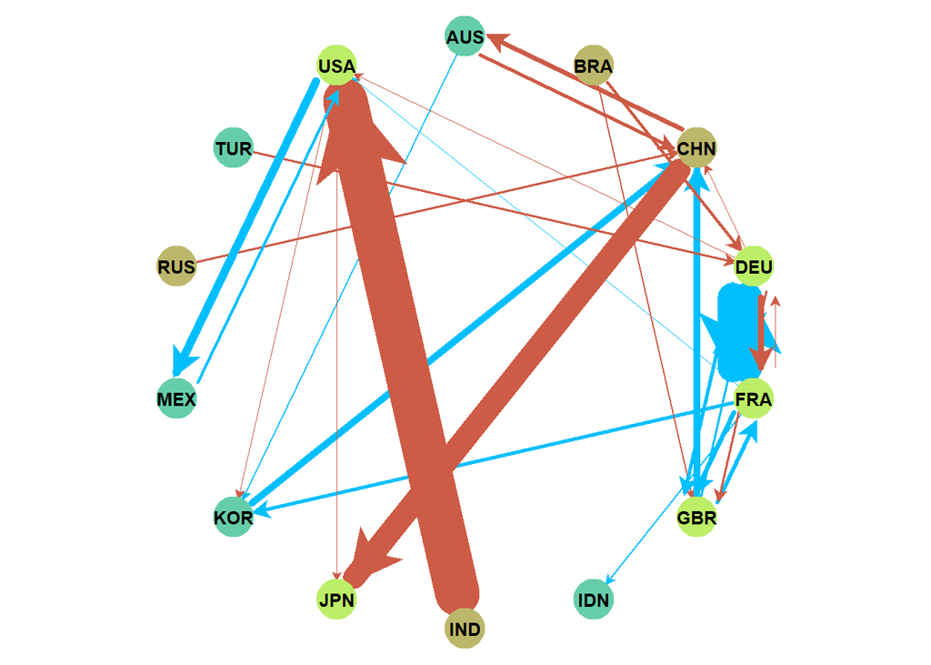

```r
# plot graph combining different types of scopes
G20net[bridges, bridges, ] |>
  multigraph(valued=TRUE, scope=c(scp, scpb), clu=club)
```

### Multilevel structures

Use `"multiplex"` package for constructing multilevel structures, which in this case are in two flavours:

- Actor co-affiliations
- Binomial projection of actors and events.

```r
# from CRAN
library(multiplex)
# use latest version
packageVersion("multiplex")
```

```
[1] '3.0.0'
```

#### Multilevel with co-affiliation of actors: Visualization

Use `"multigraph"` package for the visualization that is based on graphical scopes for the plots.

```r
# define common multilevel scope
scpml <- list(cex=5, pos=0, lty=1, pch=c(21,15), ecol=c("#00BFFF","#CD5B45","#FF7F24"),
              ffamily="mono", fsize=10)
```

```r
# vertex colors for co-affiliations
vtcc <- list(vcol=c("#BCEE68","#BDB76B","#66CDAA","#838B8B"))
```

Starting in `"multigraph"` v0.99, use `NULL` to class all members in domain or co-domain.

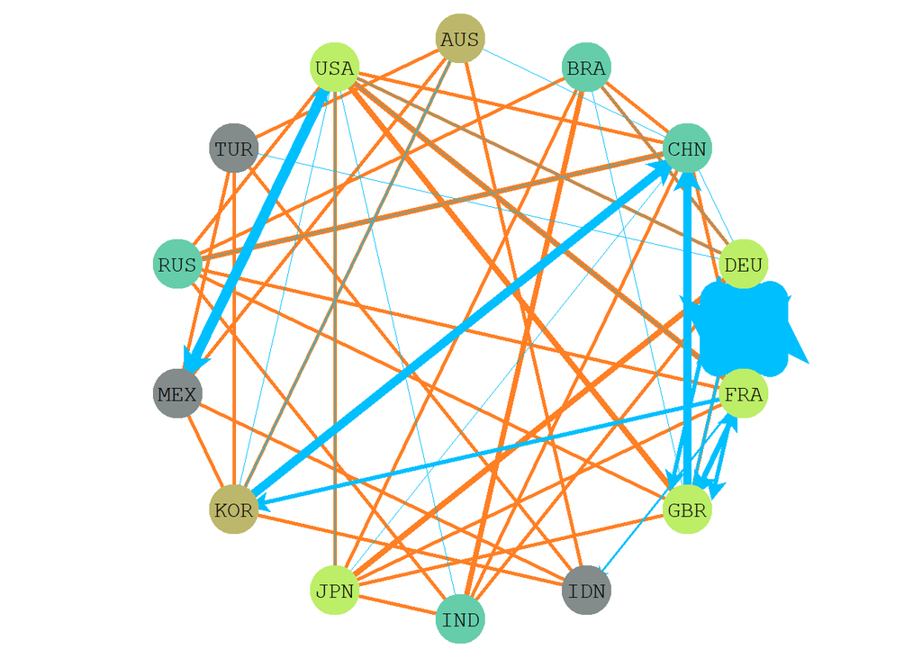

Multilevel with co-affiliation of actors

```r
# valued multigraph for co-membership with circular layout
G20net[bridges, bridges, ] |> mlvl(y=G20b, type="cn2") |>
  multigraph::mlgraph(layout="circ", nr=NULL, valued=TRUE, scope=c(scpml,vtcc),
+                     clu=list(acc[bridges], NULL) )
```

#### Multilevel with binomial projection: Visualization

```r
# vertex colors for binomial projection
vtcb <- list(vcol=c("#BCEE68","#BDB76B","#66CDAA","#838B8B","#FF7F00"))
```

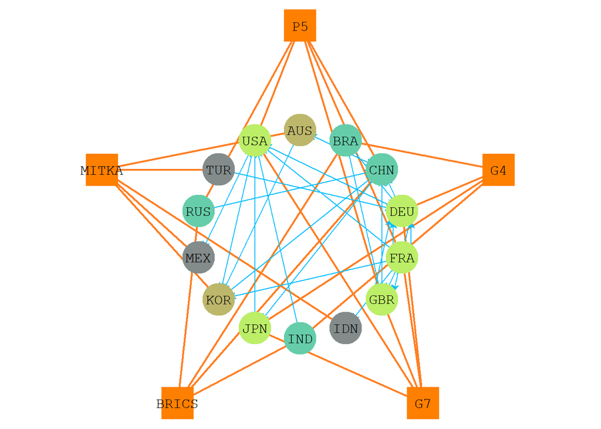

Multilevel with binomial projection

```r
# concentric graph with 2 radii for organizations as vertices
G20net[bridges, bridges, ] |> mlvl(y=G20b, type="bpn") |>
  multigraph::mlgraph(layout="conc", nr=NULL, scope=c(scpml,vtcb),
+                   clu=list(acc[bridges], NULL) )
```

### Positional analysis multilevel

For the algebraic analysis, construct first a positional system of the G20 countries network with the clustering information bridge countries affiliations.

```r
# vector, counter, and just non-overlapping affiliations in 'G20b'
club <- vector(length=nrow(G20b))
k <- 1L
for(i in seq(3,5)) {
    club[which(G20b[,i]==1)] <- k
    k <- k + 1L
}
```

```r
# Positional system for actors with clustering information
G20bn <- G20net[bridges, bridges, ] |>
  multiplex::reduc(valued=TRUE, lbs=c("G7.C","BRICS.C","MITKA.C"), clu=club)
G20bn
```

```
, , M

         G7.C BRICS.C MITKA.C
G7.C    19249    1734    3538
BRICS.C     0       0       0
MITKA.C   752    1743     412

, , H

         G7.C BRICS.C MITKA.C
G7.C     3050     296     293
BRICS.C 17781     584    1187
MITKA.C   551     860       0
```

```r
# Positional system for events ('row' option with two-mode data)
G20bm <- G20b |> multiplex::reduc(valued=TRUE, lbs=c("G7.C","BRICS.C","MITKA.C"),
                                  clu=club, row=TRUE)
```

```
        P5 G4 G7 BRICS MITKA
G7.C     3  2  5     0     0
BRICS.C  2  2  0     4     0
MITKA.C  0  0  0     0     5
```

#### Multilevel positional system

The multilevel positional system takes $X^B_{G20b}$ and $X^V_{G20b}$

```r
# multilevel positional system with binomial projection and symmetric co-domain
G20bnm <- mlvl(G20bn, G20bm, lbs=c("M","H","O"), symCdm=TRUE)
```

```
$mlnet
, , M

         G7.C BRICS.C MITKA.C P5 G4 G7 BRICS MITKA
G7.C    19249    1734    3538  0  0  0     0     0
BRICS.C     0       0       0  0  0  0     0     0
MITKA.C   752    1743     412  0  0  0     0     0
P5          0       0       0  0  0  0     0     0
G4          0       0       0  0  0  0     0     0
G7          0       0       0  0  0  0     0     0
BRICS       0       0       0  0  0  0     0     0
MITKA       0       0       0  0  0  0     0     0

, , H

         G7.C BRICS.C MITKA.C P5 G4 G7 BRICS MITKA
G7.C     3050     296     293  0  0  0     0     0
BRICS.C 17781     584    1187  0  0  0     0     0
MITKA.C   551     860       0  0  0  0     0     0
P5          0       0       0  0  0  0     0     0
G4          0       0       0  0  0  0     0     0
G7          0       0       0  0  0  0     0     0
BRICS       0       0       0  0  0  0     0     0
MITKA       0       0       0  0  0  0     0     0

, , O

        G7.C BRICS.C MITKA.C P5 G4 G7 BRICS MITKA
G7.C       0       0       0  3  2  5     0     0
BRICS.C    0       0       0  2  2  0     4     0
MITKA.C    0       0       0  0  0  0     0     5
P5         3       2       0  0  0  0     0     0
G4         2       2       0  0  0  0     0     0
G7         5       0       0  0  0  0     0     0
BRICS      0       4       0  0  0  0     0     0
MITKA      0       0       5  0  0  0     0     0


$lbs
$lbs$dm
[1] "G7.C"    "BRICS.C" "MITKA.C"

$lbs$cdm
[1] "P5"    "G4"    "G7"    "BRICS" "MITKA"


$modes
[1] "1M" "1M" "2M"

attr(,"class")
[1] "Multilevel" "bpn"
```

#### Visualization

```r
# scope for multilevel positional system
scpPSml <- list(cex=6, pch=21:22, ecol=c("#00BFFF","#CD5B45","#FF7F24"),
                vcol=c("#BCEE68","#66CDAA","#A0A17B","#FF7F00"), vcol0=8,
                clu=c(1:3,rep(4,5)), pos=0, fsize=11, rot=29, swp=TRUE)
```

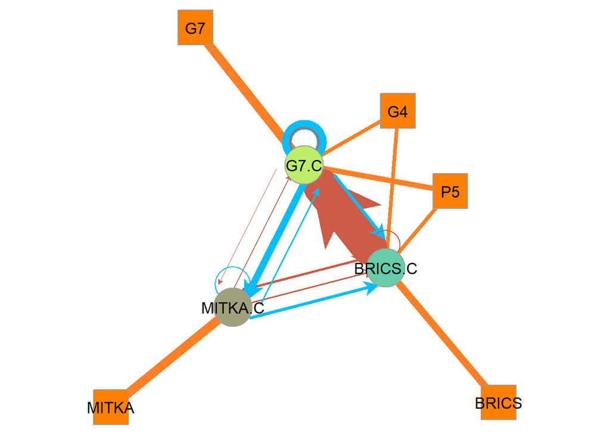

Valued multigraph of multilevel positional system with binomial projection

```r
# plot the binomial proyection of the multilevel positional system
multigraph::mlgraph(G20bnm , valued=TRUE, layout="force", seed=1, scope=scpPSml)
```

## Relational structure of multilevel configurations

Now is time for the algebraic analysis of G20 Countries network is a multilevel, multiplex and valued structure

The bipartite positional system of the network is in `G20bm`.

```r
# G20 with bridges
G20bm
```

```
        P5 G4 G7 BRICS MITKA
G7.C     3  2  5     0     0
BRICS.C  2  2  0     4     0
MITKA.C  0  0  0     0     5
```

```r
# data frame or edge list into an array without G4 and renaming MITKA
G20bma <- G20bm[,c(1,3:5)] |>
  edgel(attr=TRUE, rownames=TRUE, dichot=TRUE)
dimnames(G20bma)[[3]][4] <- "A"
G20bma
```

```
, , P5

        G7.C BRICS.C MITKA.C
G7.C       1       0       0
BRICS.C    0       1       0
MITKA.C    0       0       0

, , G7

        G7.C BRICS.C MITKA.C
G7.C       1       0       0
BRICS.C    0       0       0
MITKA.C    0       0       0

, , BRICS

        G7.C BRICS.C MITKA.C
G7.C       0       0       0
BRICS.C    0       1       0
MITKA.C    0       0       0

, , A

        G7.C BRICS.C MITKA.C
G7.C       0       0       0
BRICS.C    0       0       0
MITKA.C    0       0       1
```

#### Binding networks

When networks are represented by matrices or arrays for multiplex structures, it is possible to bind them even if they have different sets of nodes.

```r
# bind trade relations with actors affiliations into a single array
G20bnm <- multiplex::zbind(G20bn, G20bma)
```

```
, , M

         G7.C BRICS.C MITKA.C
G7.C    19249    1734    3538
BRICS.C     0       0       0
MITKA.C   752    1743     412

, , H

         G7.C BRICS.C MITKA.C
G7.C     3050     296     293
BRICS.C 17781     584    1187
MITKA.C   551     860       0

, , P5

        G7.C BRICS.C MITKA.C
G7.C       1       0       0
BRICS.C    0       1       0
MITKA.C    0       0       0

, , G7

        G7.C BRICS.C MITKA.C
G7.C       1       0       0
BRICS.C    0       0       0
MITKA.C    0       0       0

, , BRICS

        G7.C BRICS.C MITKA.C
G7.C       0       0       0
BRICS.C    0       1       0
MITKA.C    0       0       0

, , A

        G7.C BRICS.C MITKA.C
G7.C       0       0       0
BRICS.C    0       0       0
MITKA.C    0       0       1
```

### Semigroup structure and Green’s relations

Both within and cross domain relations are in `G20bnm`, and construct its relational structure.

```r
# semigroup with simplified strings
G20bnm |>
  semigroup(type="symbolic", smpl=TRUE) |>
  green.rel()
```

```
$S
     M   H   P   G   B   A  MP  MG  MB  MA HM  HP  HG  HB  HA PM PH PA BH AM  AH HMA HAH PMP PMB PMA PHG PHB BHP BHG BHA AMG AMB
M    M   M  MP  MG  MB  MA  MP  MG  MB  MA  M  MP  MG  MB  MA  M  M PA  M  M  MP  MA  MP  MP  MB  MA  MG  MB  MP  MG  MA  MG  MB
H   HM  HM  HP  HG  HB  HA  HP  HG  HB HMA HM  HP  HG  HB HMA HM HM PA HM PH HAH HMA  HP  HP  HB HMA  HG  HB  HP  HG HMA PHG PHB
P   PM  PH   P   G   B  PA PMP   G PMB PMA PH HAH PHG PHB  HA PM PH PA BH PA  PA  HA HAH PMP PMB PMA PHG PHB BHP BHG BHA  PA  PA
G   PM  PM   G   G  PA  PA PMP   G PMB PMA PM PMP   G PMB PMA PM PM PA PA PA  PA PMA PMP PMP PMB PMA   G PMB  PA  PA  PA  PA  PA
B   PA  BH   B  PA   B  PA  PA  PA  PA  PA BH BHP BHG   B BHA PA BH PA BH PA  PA BHA BHP  PA  PA  PA BHG   B BHP BHG BHA  PA  PA
A   AM  AH  PA  PA  PA   A  AH AMG AMB   A AM  AH AMG AMB  PA PA PA PA PA AM  AH   A  PA  PA  PA  PA  PA  PA  PA  PA  PA AMG AMB
MP   M   M  MP  MG  MB  PA  MP  MG  MB  MA  M  MP  MG  MB  MA  M  M PA  M PA  PA  MA  MP  MP  MB  MA  MG  MB  MP  MG  MA  PA  PA
MG   M   M  MG  MG  PA  PA  MP  MG  MB  MA  M  MP  MG  MB  MA  M  M PA PA PA  PA  MA  MP  MP  MB  MA  MG  MB  PA  PA  PA  PA  PA
MB  PA   M  MB  PA  MB  PA  PA  PA  PA  PA  M  MP  MG  MB  MA PA  M PA  M PA  PA  MA  MP  PA  PA  PA  MG  MB  MP  MG  MA  PA  PA
MA   M  MP  PA  PA  PA  MA  MP  MG  MB  MA  M  MP  MG  MB  PA PA PA PA PA  M  MP  MA  PA  PA  PA  PA  PA  PA  PA  PA  PA  MG  MB
HM  HM  HM  HP  HG  HB HMA  HP  HG  HB HMA HM  HP  HG  HB HMA HM HM PA HM HM  HP HMA  HP  HP  HB HMA  HG  HB  HP  HG HMA  HG  HB
HP  HM  HM  HP  HG  HB  PA  HP  HG  HB HMA HM  HP  HG  HB HMA HM HM PA HM PA  PA HMA  HP  HP  HB HMA  HG  HB  HP  HG HMA  PA  PA
HG  HM  HM  HG  HG  PA  PA  HP  HG  HB HMA HM  HP  HG  HB HMA HM HM PA PA PA  PA HMA  HP  HP  HB HMA  HG  HB  PA  PA  PA  PA  PA
HB  PA  HM  HB  PA  HB  PA  PA  PA  PA  PA HM  HP  HG  HB HMA PA HM PA HM PA  PA HMA  HP  PA  PA  PA  HG  HB  HP  HG HMA  PA  PA
HA  PH HAH  PA  PA  PA  HA HAH PHG PHB  HA PH HAH PHG PHB  PA PA PA PA PA PH HAH  HA  PA  PA  PA  PA  PA  PA  PA  PA  PA PHG PHB
PM  PM  PM PMP   G PMB PMA PMP   G PMB PMA PM PMP   G PMB PMA PM PM PA PM PM PMP PMA PMP PMP PMB PMA   G PMB PMP   G PMA   G PMB
PH  PH  PH HAH PHG PHB  HA HAH PHG PHB  HA PH HAH PHG PHB  HA PH PH PA PH PH HAH  HA HAH HAH PHB  HA PHG PHB HAH PHG  HA PHG PHB
PA  PA  PA  PA  PA  PA  PA  PA  PA  PA  PA PA  PA  PA  PA  PA PA PA PA PA PA  PA  PA  PA  PA  PA  PA  PA  PA  PA  PA  PA  PA  PA
BH  BH  BH BHP BHG   B BHA BHP BHG   B BHA BH BHP BHG   B BHA BH BH PA BH BH BHP BHA BHP BHP   B BHA BHG   B BHP BHG BHA BHG   B
AM  AM  AM  AH AMG AMB   A  AH AMG AMB   A AM  AH AMG AMB   A AM AM PA AM AM  AH   A  AH  AH AMB   A AMG AMB  AH AMG   A AMG AMB
AH  AM  AM  AH AMG AMB  PA  AH AMG AMB   A AM  AH AMG AMB   A AM AM PA AM PA  PA   A  AH  AH AMB   A AMG AMB  AH AMG   A  PA  PA
HMA HM  HP  PA  PA  PA HMA  HP  HG  HB HMA HM  HP  HG  HB  PA PA PA PA PA HM  HP HMA  PA  PA  PA  PA  PA  PA  PA  PA  PA  HG  HB
HAH PH  PH HAH PHG PHB  PA HAH PHG PHB  HA PH HAH PHG PHB  HA PH PH PA PH PA  PA  HA HAH HAH PHB  HA PHG PHB HAH PHG  HA  PA  PA
PMP PM  PM PMP   G PMB  PA PMP   G PMB PMA PM PMP   G PMB PMA PM PM PA PM PA  PA PMA PMP PMP PMB PMA   G PMB PMP   G PMA  PA  PA
PMB PA  PM PMB  PA PMB  PA  PA  PA  PA  PA PM PMP   G PMB PMA PA PM PA PM PA  PA PMA PMP  PA  PA  PA   G PMB PMP   G PMA  PA  PA
PMA PM PMP  PA  PA  PA PMA PMP   G PMB PMA PM PMP   G PMB  PA PA PA PA PA PM PMP PMA  PA  PA  PA  PA  PA  PA  PA  PA  PA   G PMB
PHG PH  PH PHG PHG  PA  PA HAH PHG PHB  HA PH HAH PHG PHB  HA PH PH PA PA PA  PA  HA HAH HAH PHB  HA PHG PHB  PA  PA  PA  PA  PA
PHB PA  PH PHB  PA PHB  PA  PA  PA  PA  PA PH HAH PHG PHB  HA PA PH PA PH PA  PA  HA HAH  PA  PA  PA PHG PHB HAH PHG  HA  PA  PA
BHP BH  BH BHP BHG   B  PA BHP BHG   B BHA BH BHP BHG   B BHA BH BH PA BH PA  PA BHA BHP BHP   B BHA BHG   B BHP BHG BHA  PA  PA
BHG BH  BH BHG BHG  PA  PA BHP BHG   B BHA BH BHP BHG   B BHA BH BH PA PA PA  PA BHA BHP BHP   B BHA BHG   B  PA  PA  PA  PA  PA
BHA BH BHP  PA  PA  PA BHA BHP BHG   B BHA BH BHP BHG   B  PA PA PA PA PA BH BHP BHA  PA  PA  PA  PA  PA  PA  PA  PA  PA BHG   B
AMG AM  AM AMG AMG  PA  PA  AH AMG AMB   A AM  AH AMG AMB   A AM AM PA PA PA  PA   A  AH  AH AMB   A AMG AMB  PA  PA  PA  PA  PA
AMB PA  AM AMB  PA AMB  PA  PA  PA  PA  PA AM  AH AMG AMB   A PA AM PA AM PA  PA   A  AH  PA  PA  PA AMG AMB  AH AMG   A  PA  PA

$ord
[1] 33

$st
```

[output cut: 48 more lines]

```
HP  HM HM HM HM HM PA | HM  | HP  | HG  HG  HG  HG  HG  PA  | HB  HB  HB  HB  HB  PA  | PA  HMA HMA HMA HMA HMA | HP  HP  PA  HP  HP  HP  | PA
HG  HM HM HM HM PA PA | HM  | HG  | HG  HG  HG  HG  PA  PA  | PA  HB  HB  HB  HB  PA  | PA  HMA HMA HMA HMA PA  | HP  HP  PA  HP  HP  PA  | PA
HB  PA HM PA HM HM PA | HM  | HB  | PA  PA  HG  HG  HG  PA  | HB  PA  HB  PA  HB  PA  | PA  PA  HMA HMA PA  HMA | PA  HP  PA  HP  PA  HP  | PA
HMA HM HM PA PA PA HM | HP  | PA  | PA  HG  HG  PA  PA  HG  | PA  HB  HB  PA  PA  HB  | HMA HMA PA  HMA PA  PA  | HP  HP  HP  PA  PA  PA  | PA
    -  -  -  -  -  -  - -   - -   - -   -   -   -   -   -   - -   -   -   -   -   -   - -   -   -   -   -   -   - -   -   -   -   -   -   - -
HA  PH PH PA PA PA PH | HAH | PA  | PA  PHG PHG PA  PA  PHG | PA  PHB PHB PA  PA  PHB | HA  HA  PA  HA  PA  PA  | HAH HAH HAH PA  PA  PA  | PA
PH  PH PH PH PH PH PH | PH  | HAH | PHG PHG PHG PHG PHG PHG | PHB PHB PHB PHB PHB PHB | HA  HA  HA  HA  HA  HA  | HAH HAH HAH HAH HAH HAH | PA
HAH PH PH PH PH PH PA | PH  | HAH | PHG PHG PHG PHG PHG PA  | PHB PHB PHB PHB PHB PA  | PA  HA  HA  HA  HA  HA  | HAH HAH PA  HAH HAH HAH | PA
PHG PH PH PH PH PA PA | PH  | PHG | PHG PHG PHG PHG PA  PA  | PA  PHB PHB PHB PHB PA  | PA  HA  HA  HA  HA  PA  | HAH HAH PA  HAH HAH PA  | PA
PHB PA PH PA PH PH PA | PH  | PHB | PA  PA  PHG PHG PHG PA  | PHB PA  PHB PA  PHB PA  | PA  PA  HA  HA  PA  HA  | PA  HAH PA  HAH PA  HAH | PA
    -  -  -  -  -  -  - -   - -   - -   -   -   -   -   -   - -   -   -   -   -   -   - -   -   -   -   -   -   - -   -   -   -   -   -   - -
PA  PA PA PA PA PA PA | PA  | PA  | PA  PA  PA  PA  PA  PA  | PA  PA  PA  PA  PA  PA  | PA  PA  PA  PA  PA  PA  | PA  PA  PA  PA  PA  PA  | PA

attr(,"class")
[1] "Semigroup"  "Green.Rels"
```

### Partial order structure

The representative strings partial order and equations with dichotomous relations are

```r
# disable valued option in strings to speed up computation
G20bnm |>
  strings(valued=FALSE, smpl=TRUE) |>
  partial.order()
```

```
    M H P G B A MP MG MB MA HM HP HG HB HA PM PH PA BH AM AH HMA HAH PMP PMB PMA PHG PHB BHP BHG BHA AMG AMB
M   1 0 0 0 0 0  0  0  0  0  1  0  0  0  0  0  0  0  0  0  0   0   0   0   0   0   0   0   0   0   0   0   0
H   0 1 0 0 0 0  0  0  0  0  1  0  0  0  0  0  0  0  0  0  0   0   0   0   0   0   0   0   0   0   0   0   0
P   0 1 1 0 0 0  0  0  0  0  1  1  0  0  0  0  1  0  0  0  0   0   1   0   0   0   0   0   0   0   0   0   0
G   1 1 1 1 0 0  1  1  0  0  1  1  1  0  0  1  1  0  0  0  0   0   1   1   0   0   1   0   0   0   0   0   0
B   0 1 1 0 1 0  0  0  0  0  1  1  0  1  0  0  1  0  1  0  0   0   1   0   0   0   0   1   1   0   0   0   0
A   1 0 0 0 0 1  0  0  0  1  1  0  0  0  0  0  0  0  0  1  0   1   0   0   0   0   0   0   0   0   0   0   0
MP  1 1 0 0 0 0  1  0  0  0  1  1  0  0  0  0  0  0  0  0  0   0   0   0   0   0   0   0   0   0   0   0   0
MG  1 1 0 0 0 0  1  1  0  0  1  1  1  0  0  0  0  0  0  0  0   0   0   0   0   0   0   0   0   0   0   0   0
MB  1 1 0 0 0 0  1  0  1  0  1  1  0  1  0  0  0  0  0  0  0   0   0   0   0   0   0   0   0   0   0   0   0
MA  1 0 0 0 0 0  0  0  0  1  1  0  0  0  0  0  0  0  0  0  0   1   0   0   0   0   0   0   0   0   0   0   0
HM  0 0 0 0 0 0  0  0  0  0  1  0  0  0  0  0  0  0  0  0  0   0   0   0   0   0   0   0   0   0   0   0   0
HP  0 1 0 0 0 0  0  0  0  0  1  1  0  0  0  0  0  0  0  0  0   0   0   0   0   0   0   0   0   0   0   0   0
HG  0 1 0 0 0 0  0  0  0  0  1  1  1  0  0  0  0  0  0  0  0   0   0   0   0   0   0   0   0   0   0   0   0
HB  0 1 0 0 0 0  0  0  0  0  1  1  0  1  0  0  0  0  0  0  0   0   0   0   0   0   0   0   0   0   0   0   0
HA  0 1 0 0 0 0  0  0  0  0  1  0  0  0  1  0  1  0  0  0  0   1   0   0   0   0   0   0   0   0   0   0   0
PM  1 1 0 0 0 0  0  0  0  0  1  0  0  0  0  1  1  0  0  0  0   0   0   0   0   0   0   0   0   0   0   0   0
PH  0 1 0 0 0 0  0  0  0  0  1  0  0  0  0  0  1  0  0  0  0   0   0   0   0   0   0   0   0   0   0   0   0
PA  1 1 1 1 1 1  1  1  1  1  1  1  1  1  1  1  1  1  1  1  1   1   1   1   1   1   1   1   1   1   1   1   1
BH  0 1 0 0 0 0  0  0  0  0  1  0  0  0  0  0  1  0  1  0  0   0   0   0   0   0   0   0   0   0   0   0   0
AM  1 0 0 0 0 0  0  0  0  0  1  0  0  0  0  0  0  0  0  1  0   0   0   0   0   0   0   0   0   0   0   0   0
AH  1 1 0 0 0 0  1  0  0  0  1  1  0  0  0  0  0  0  0  1  1   0   0   0   0   0   0   0   0   0   0   0   0
HMA 0 0 0 0 0 0  0  0  0  0  1  0  0  0  0  0  0  0  0  0  0   1   0   0   0   0   0   0   0   0   0   0   0
HAH 0 1 0 0 0 0  0  0  0  0  1  1  0  0  0  0  1  0  0  0  0   0   1   0   0   0   0   0   0   0   0   0   0
PMP 1 1 0 0 0 0  1  0  0  0  1  1  0  0  0  1  1  0  0  0  0   0   1   1   0   0   0   0   0   0   0   0   0
PMB 1 1 0 0 0 0  1  0  1  0  1  1  0  1  0  1  1  0  0  0  0   0   1   1   1   0   0   1   0   0   0   0   0
PMA 1 1 0 0 0 0  0  0  0  1  1  0  0  0  1  1  1  0  0  0  0   1   0   0   0   1   0   0   0   0   0   0   0
PHG 0 1 0 0 0 0  0  0  0  0  1  1  1  0  0  0  1  0  0  0  0   0   1   0   0   0   1   0   0   0   0   0   0
PHB 0 1 0 0 0 0  0  0  0  0  1  1  0  1  0  0  1  0  0  0  0   0   1   0   0   0   0   1   0   0   0   0   0
BHP 0 1 0 0 0 0  0  0  0  0  1  1  0  0  0  0  1  0  1  0  0   0   1   0   0   0   0   0   1   0   0   0   0
BHG 0 1 0 0 0 0  0  0  0  0  1  1  1  0  0  0  1  0  1  0  0   0   1   0   0   0   1   0   1   1   0   0   0
BHA 0 1 0 0 0 0  0  0  0  0  1  0  0  0  1  0  1  0  1  0  0   1   0   0   0   0   0   0   0   0   1   0   0
AMG 1 1 0 0 0 0  1  1  0  0  1  1  1  0  0  0  0  0  0  1  1   0   0   0   0   0   0   0   0   0   0   1   0
AMB 1 1 0 0 0 0  1  0  1  0  1  1  0  1  0  0  0  0  0  1  1   0   0   0   0   0   0   0   0   0   0   0   1
attr(,"class")
[1] "Partial.Order" "strings"
```

### String relations

```r
# equations until length 3
G20bnm |>
  strings(valued=FALSE, smpl=TRUE, equat=TRUE, k=3)
```

```
$wt
, , M

        G7.C BRICS.C MITKA.C
G7.C       1       1       1
BRICS.C    0       0       0
MITKA.C    1       1       1

, , H

        G7.C BRICS.C MITKA.C
G7.C       1       1       1
BRICS.C    1       1       1
MITKA.C    1       1       0

, , P

        G7.C BRICS.C MITKA.C
G7.C       1       0       0
BRICS.C    0       1       0
MITKA.C    0       0       0

, , G

        G7.C BRICS.C MITKA.C
G7.C       1       0       0
BRICS.C    0       0       0
MITKA.C    0       0       0

, , B

        G7.C BRICS.C MITKA.C
G7.C       0       0       0
BRICS.C    0       1       0
MITKA.C    0       0       0

, , A

        G7.C BRICS.C MITKA.C
G7.C       0       0       0
```

[output cut: 271 more lines]

```
$equat$PMB
[1] "PMB" "GMB" "GHB"

$equat$PMA
[1] "PMA" "GMA" "GHA"

$equat$AMG
[1] "AMG" "AHG"

$equat$AMB
[1] "AMB" "AHB"


attr(,"class")
[1] "Strings"
```

For the plottings, relabel the strings that are in the semigroup structure in `G20bnmS`.

```r
# labeling for Cayley graph and Concept diagram comes from the semigroup
G20bnm |> semigroup(type="symbolic", smpl=TRUE) |> getElement("st")
```

```
 [1] "M"   "H"   "P"   "G"   "B"   "A"   "MP"  "MG"  "MB"  "MA"  "HM"  "HP"  "HG"  "HB"  "HA"  "PM"  "PH"  "PA"  "BH"  "AM"  "AH"  "HMA" "HAH" "PMP" "PMB" "PMA" "PHG" "PHB" "BHP" "BHG" "BHA" "AMG" "AMB"
```

```r
# assign labels from strings in semigroup
lbsc <- lbsp <-  G20bnm |> semigroup(type="symbolic", smpl=TRUE) |> getElement("st")

# significant equations to show in the Cayley graph
lbsc[which(lbsc=="m")] <- "m=mh"
lbsc[which(lbsc=="PA")] <- "Bm"
lbsc[which(lbsc=="hm")] <- "hh=hm"
lbsc[which(lbsc=="Pm")] <- "Pm=Gm=Gh"

# significant equations to show in the Concept diagram
lbsp[which(lbsp=="m")] <- "m,mh"
lbsp[which(lbsp=="PA")] <- "Bm"
lbsp[which(lbsp=="hm")] <- "hh,hm"
lbsp[which(lbsp=="Pm")] <- "Pm,Gm,Gh"
```

### Plot partially ordered semigroup

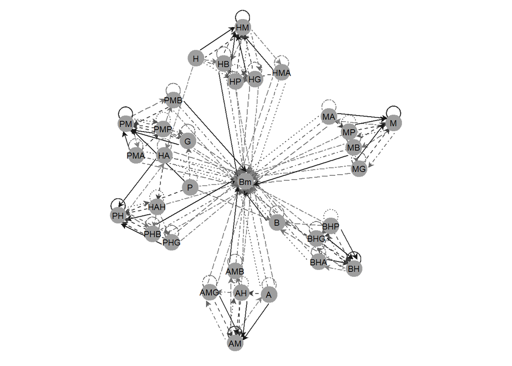

Cayley graph

```r
# use equation labels lbsc
G20bnm |>
  semigroup(type="symbolic", smpl=TRUE) |>
  ccgraph(cex=3, pos=0, col=8, lbs=lbsc, fsize=7, rot=-55)
```

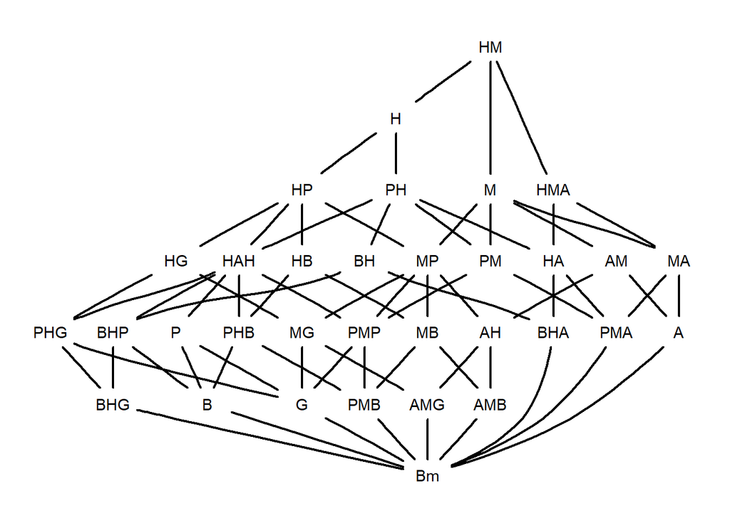

Inclusion lattice

```r
# use equation labels lbsp
G20bnm |>
  strings(valued=FALSE, smpl=TRUE) |>
  partial.order() |>
  diagram(lwd=2, lbs=lbsp, fsize=9)
```

### Concept diagram multilevel

```r
# Positional system events ('row' option for two-mode networks)
PSG20b <- G20b |> reduc(valued=TRUE, lbs=c("G7.C","BRICS.C","MITKA.C"), clu=club, row=TRUE)
```

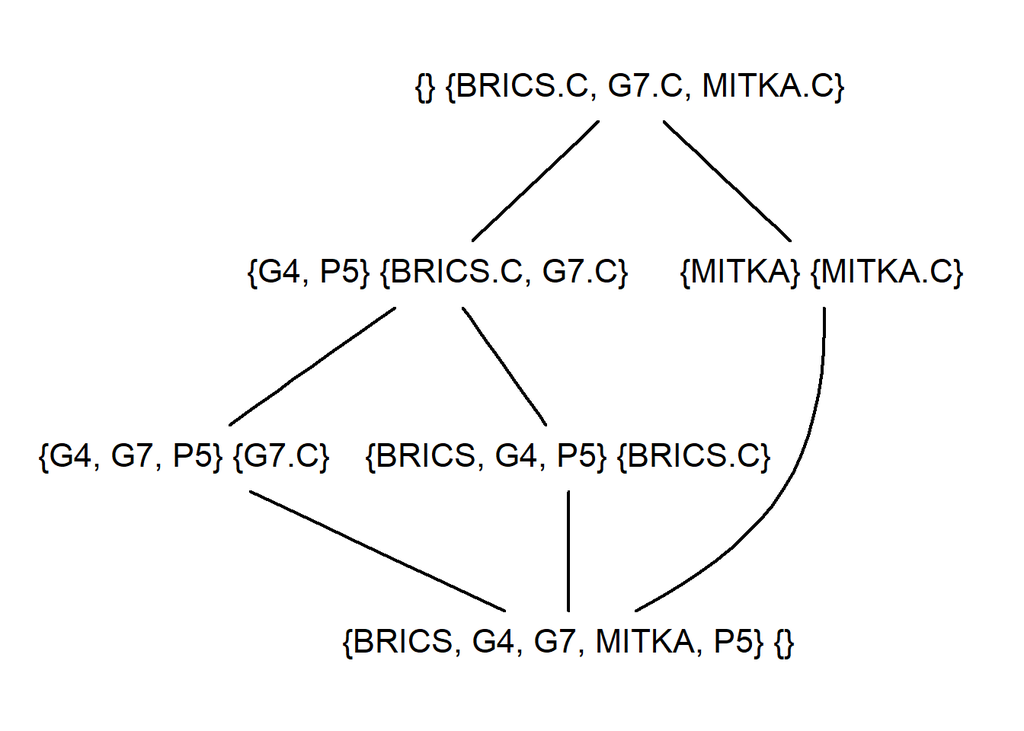

Full labeling

```r
# Galois connections with full labeling
PSG20b |>
  galois(labeling="full") |>
  partial.order(type="galois") |>
  diagram(lwd=2)
```

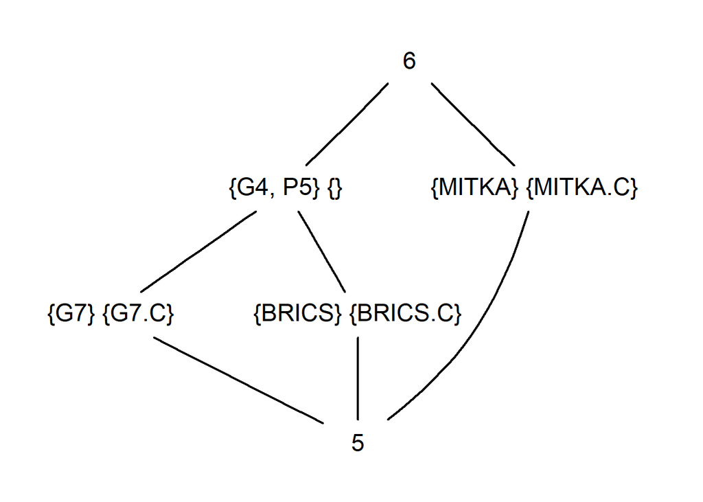

Reduced labeling

```r
# Galois connections with reduced labeling
PSG20b |>
  galois(labeling="reduced") |>
  partial.order(type="galois") |>
  diagram(lwd=2)
```

##### See also

Manuals:

- [`"multiplex"`](https://cran.r-project.org/web/packages/multiplex/multiplex.pdf)
- [`"multigraph"`](https://cran.r-project.org/web/packages/multigraph/multigraph.pdf)
- [`"sdam"`](https://github.com/mplex/cedhar/blob/master/typesetting/reports/sdam.pdf)

Vignettes:

- [Working with Two-Mode Networks in multiplex](https://cran.r-project.org/web/packages/multiplex/vignettes/TwoModeNetworks.pdf)
- [Cartographical maps and networks](https://sdam-au.github.io/sdam/articles/Maps.html)

Applications in humanities:

- [Shipwrecks network in the Mediterranean Basin (23-June-2022)](https://htmlpreview.github.io/?https://github.com/sdam-au/R_code/blob/master/HTML/Shipwrecks%20Network%20in%20the%20Mediterranean%20Basin.html)
- [Centrality measures in ORBIS Roman transport network (24-Nov-2021)](https://htmlpreview.github.io/?https://github.com/sdam-au/R_code/blob/master/HTML/Centrality%20measures%20in%20ORBIS%20Roman%20transport%20network.html)
- [ORBIS Roman World transport network (22-Sep-2021)](https://htmlpreview.github.io/?https://github.com/sdam-au/R_code/blob/master/HTML/ORBIS%20Roman%20World%20transport%20network%20centrality%20measures.html)
- [INSNA Sunbelt 2023 Website](https://www.insna.org/events/sunbelt-2023)

[back](https://github.com/mplex/sunbelt2023)